# Bike Speed and Weather

24 Nov 2014

## Bike Speed and Weather

### Project for Data Science with R: Data Analysis

Acknowledgements:

- **Citibike operated by NYC Bike Share**

  provided all primary data
- **MapQuest Open Platform Web Services**

  provided all distance and elevation data
- **Weather Underground**

  provided all weather information

## Aims

- To collect and integrate one years data from disparate data sources
- To estimate the bike speeds of the fastest riders
- To relate temperature and elevation with bike speed
- To predict journey time given weather conditions

## Citibike Data

- Substantial data available
- start station: id, lat, long, address
- end station: id, lat, long, address
- trip: start time, end time, trip duration, bike id
- user: customer or subscriber, birth year, gender

## Data Pre-processing 1

- Filter the citibike data:
- Men, Subscribers, Mon - Fri, 9.00 - 5.00pm, Workdays only (excluded holidays)
- Find the fatest riders for all the station pairs

## For Each Months Data

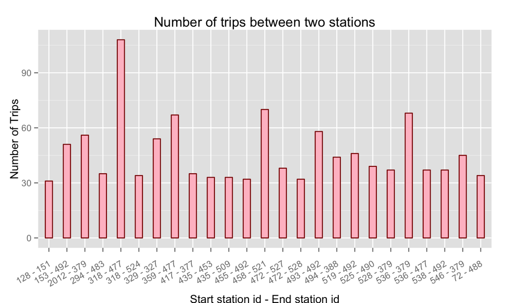

## Finding the Fatest Cyclist

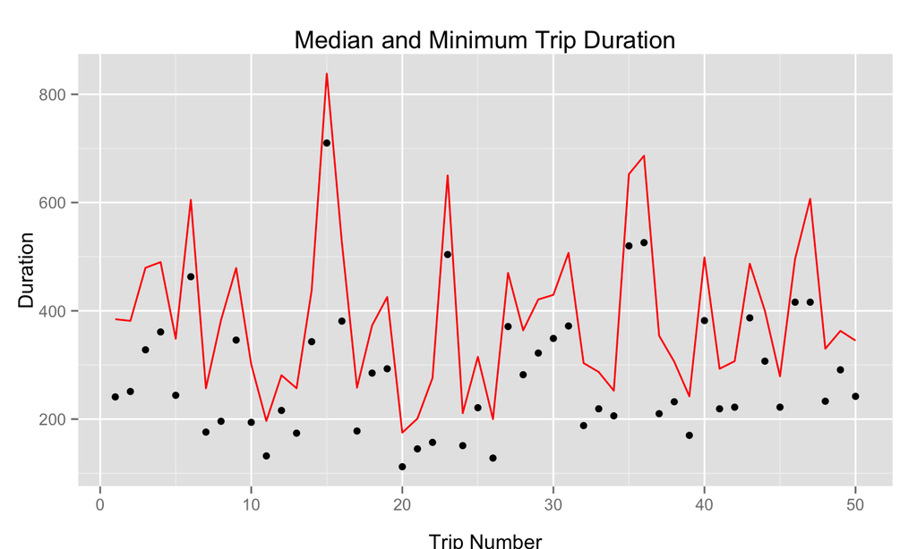

## Data Pre-processing 2

- *MapQuest API* provides a "distance" from starting lat/long to ending lat/long
- From this data derive bike speed (in mph)
- Second *MapQuest API* call provides elevation bewtween start and end stations
- *Wunderground API* returns historical weather data close to the starting time of the trip
- Obtain observations for temp, windspeed, windchill, precipitation, humidity

## Do the derived bike speeds seem credible?

- Pablo Jensen at the École Normale Supérieure de Lyon, found:

  Over an average trip, cyclists travel 1.55 miles in 14.7 minutes

  Average speed ~ 6.2 mph.

  Rush hour average speed ~ 9.3 mph
- Citibike data speed estimates ~ 10.6 mph
- Perhaps the MapQuest route over-estimate the distance.

## Data Visualization 1 - Speed

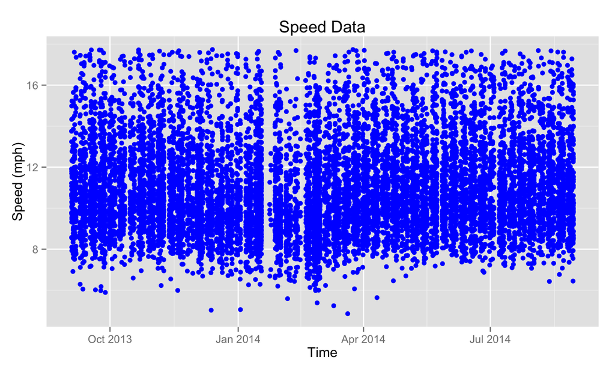

## Data Visualization 2 - Temp

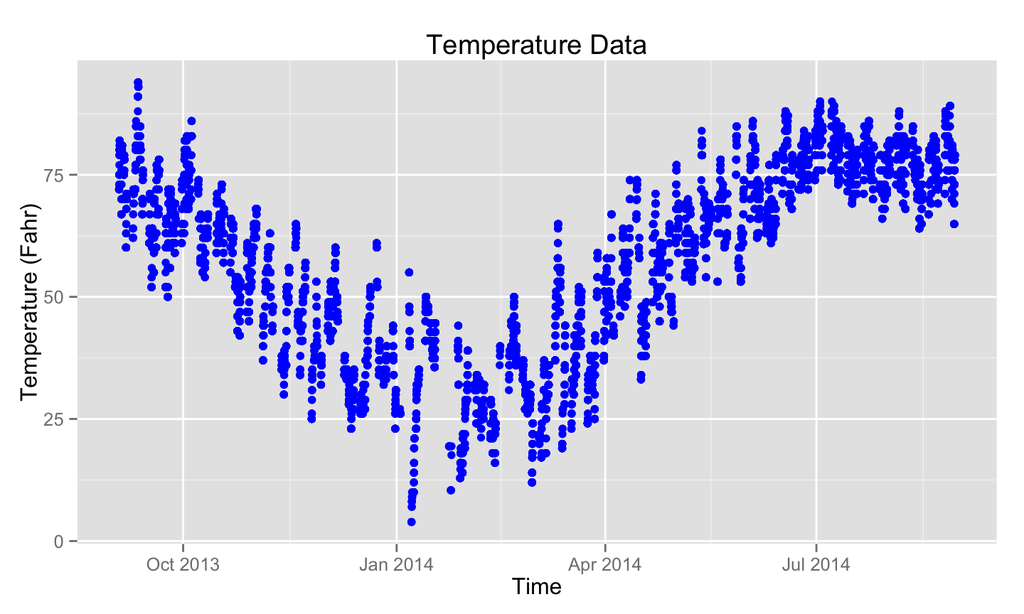

## Data Visualization 3 - Elevation

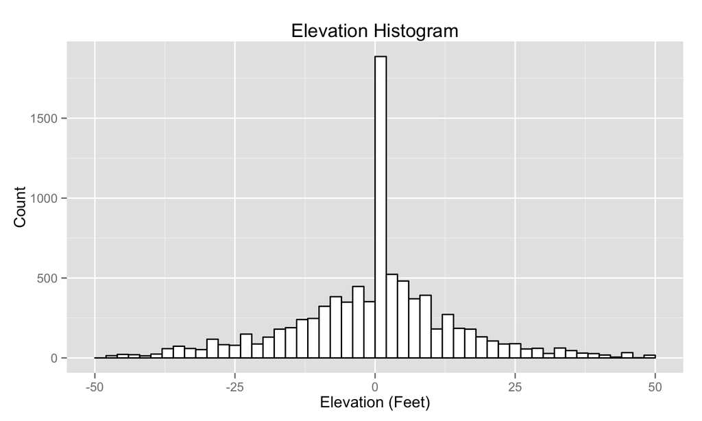

## Other Weather Variables?

- Hoped to use precipitation (rain), but the data reported from Wunderground was sparse.
- Public blogs suggest they have a bug in their historical data reporting for rainfall!
- Windspeed: Data sparsely reported. Mostly reported as 0 mph.
- Humidity: Correlated more with temperature
- Windchill: Data sparsely reported. Correlated with temperature

## Pairwise correlations

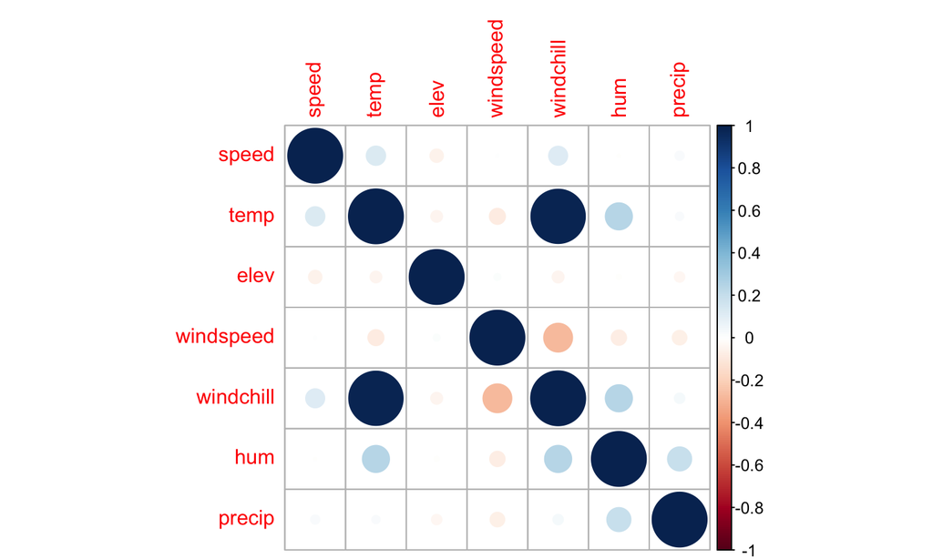

## Speed and Temperature

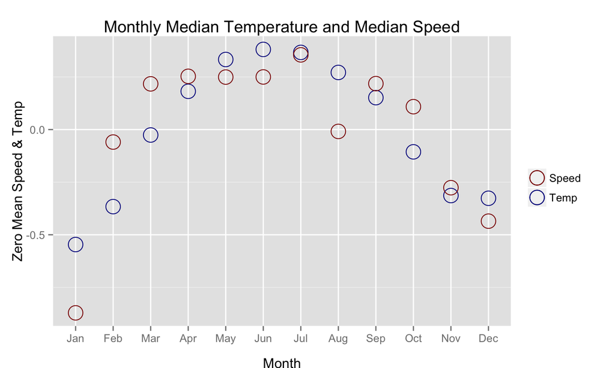

## Selecting the Model

- Randomly split data into training and test set (50:50)
- BoxCox plot: transform speed into log(speed)
- Normalized the data (zero mean and unit variance)
- Tested 5 models relating speed to temperature and elevation
- "Best" model: Log(Speed) ~ temp + temp-squared + elev
- "Best" meaning lowest MSE on the unseen test data, and lowest AIC
- MSE Test = 0.99

## Conclusions

- Speed and temperature are correlated, but does the temperature *result* in a different speed?
- Temperature is known to be very important to physiology.
- Incline and speed are related, but inclines in NYC are minimal
- The route of each cyclist is not actually known but speed can be approximated
- It would be interesting to know the true speeds of the fastest cyclists
- Data from disparate sources can be utilized in an integrated and therefore meaningful manner